# DATA 605 - Final Project

Don Padmaperuma

```r
library(kableExtra)
```

## Problem 1

Using R, generate a random variable X that has 10,000 random uniform numbers from 1 to N, where N can be any number of your choosing greater than or equal to 6. Then generate a random variable Y that has 10,000 random normal numbers with a mean of (N+1)/2.

```r
set.seed(123)
N <- 10
X <-  runif(10000, min=0, max=N)
Y <- rnorm(10000, mean=(N+1)/2, sd=(N+1)/2)# mean and standard deviation is (N+1)/2
df <- data.frame(cbind(X, Y))
summary(X)
```

```
##     Min.  1st Qu.   Median     Mean  3rd Qu.     Max.
## 0.000653 2.528918 4.945676 4.975494 7.433941 9.999414
```

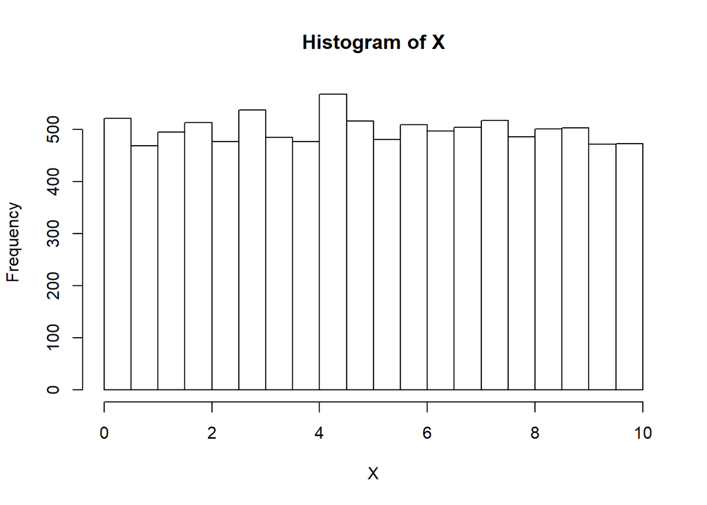

```r
hist(X)
```

```r
summary(Y)
```

```
##    Min. 1st Qu.  Median    Mean 3rd Qu.    Max.
## -15.649   1.841   5.475   5.511   9.330  26.663
```

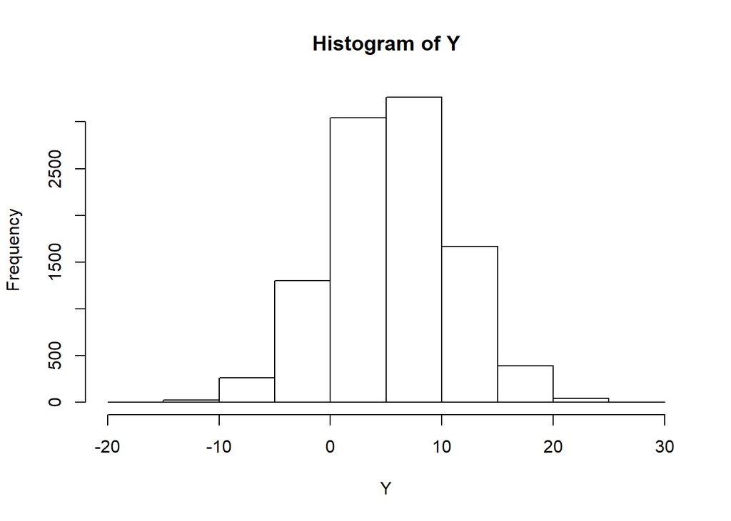

```r
hist(Y)
```

### Probability Calculate as a minimum the below probabilities a through c. Assume the small letter “x” is estimated as the median of the X variable, and the small letter “y” is estimated as the 1st quartile of the Y variable. Interpret the meaning of all probabilities.

```r
#set variables
#median of the X variable
x<-median(X)
x
```

```
## [1] 4.945676
```

```r
y <- quantile(Y, 0.25)
y
```

```
##      25%
## 1.840529
```

#### a. P(X>x | X>y)

```r
pXXy <- nrow(subset(df, X > x & Y > y))/10000
pXy <- nrow(subset(df, X > y))/10000
Prob_a <- (pXXy/pXy)
Prob_a
```

```
## [1] 0.4606328
```

#### b. P(X>x, Y>y)

```r
Prob_b <- nrow(subset(df, X > x & Y > y))/10000
Prob_b
```

```
## [1] 0.3756
```

#### c. P(X<x | X>y)

```r
pXXy2 <- nrow(subset(df, X < x & X > y))/10000
pXy2<- nrow(subset(df, X > y))/10000
Prob_c<-pXXy2/pXy2
Prob_c
```

```
## [1] 0.386804
```

### Investigate

Investigate whether P(X>x and Y>y)=P(X>x)P(Y>y) by building a table and evaluating the marginal and joint probabilities.

```r
matrix<-matrix( c(sum(X>x & Y<y),sum(X>x & Y>y), sum(X<x & Y<y),sum(X<x & Y>y)), nrow = 2,ncol = 2)
matrix<-cbind(matrix,c(matrix[1,1]+matrix[1,2],matrix[2,1]+matrix[2,2]))
matrix<-rbind(matrix,c(matrix[1,1]+matrix[2,1],matrix[1,2]+matrix[2,2],matrix[1,3]+matrix[2,3]))
contingency<-as.data.frame(matrix)
names(contingency) <- c("X>x","X<x", "Total")
row.names(contingency) <- c("Y<y","Y>y", "Total")
kable(contingency) %>%
  kable_styling(bootstrap_options = "bordered")
```

|  | X>x | X<x | Total |
| --- | --- | --- | --- |
| Y<y | 1244 | 1256 | 2500 |
| Y>y | 3756 | 3744 | 7500 |
| Total | 5000 | 5000 | 10000 |

```r
prob_matrix<-matrix/matrix[3,3]
contingency_p<-as.data.frame(prob_matrix)
names(contingency_p) <- c("X>x","X<x", "Total")
row.names(contingency_p) <- c("Y<y","Y>y", "Total")
kable(round(contingency_p,2)) %>%
  kable_styling(bootstrap_options = "bordered")
```

|  | X>x | X<x | Total |
| --- | --- | --- | --- |
| Y<y | 0.12 | 0.13 | 0.25 |
| Y>y | 0.38 | 0.37 | 0.75 |
| Total | 0.50 | 0.50 | 1.00 |

Compute P(X>x)P(Y>y)

```r
prob_matrix[3,1]*prob_matrix[2,3]
```

```
## [1] 0.375
```

Compute P(X>x and Y>y)

```r
round(prob_matrix[2,1],digits = 3)
```

```
## [1] 0.376
```

Since the values are so similar/close we would conclude that X and Y are indeed independent.

### Fisher’s Exact Test and the Chi Square Test

Check to see if independence holds by using Fisher’s Exact Test and the Chi Square Test. What is the difference between the two? Which is most appropriate?

#### Fisher’s Exact Test

```r
fisher.test(matrix,simulate.p.value=TRUE)
```

```
##
##  Fisher's Exact Test for Count Data with simulated p-value (based
##  on 2000 replicates)
##
## data:  matrix
## p-value = 0.9985
## alternative hypothesis: two.sided
```

#### Chi Square Test

```r
chisq.test(matrix, correct = TRUE)
```

```
##
##  Pearson's Chi-squared test
##
## data:  matrix
## X-squared = 0.0768, df = 4, p-value = 0.9993
```

P values obtained from both test seems to greater than 0.05 making null hypothesis H0 acceptable.

Fisher’s exact test is practically applied only in analysis of small samples but actually it is valid for all sample sizes. While the chi-squared test relies on an approximation, Fisher’s exact test is one of exact tests.

As Fisher’s exact test is used in analysis of small samples, chi-squared test is appropriate in this case.

## Problem 2

The House Prices: Advanced Regression Techniques competition. https://www.kaggle.com/c/house-prices-advanced-regression-techniques.

```r
# Import training data
train <- read.csv('https://raw.githubusercontent.com/gpadmaperuma/DATA-605/master/Final%20Project/train.csv')
test <- read.csv('https://raw.githubusercontent.com/gpadmaperuma/DATA-605/master/Final%20Project/test.csv')
test$SalePrice <- 0
```

### Descriptive and Inferential Statistics

#### Summary of Training data

```r
summary(train)
```

```
##        Id           MSSubClass       MSZoning     LotFrontage
##  Min.   :   1.0   Min.   : 20.0   C (all):  10   Min.   : 21.00
##  1st Qu.: 365.8   1st Qu.: 20.0   FV     :  65   1st Qu.: 59.00
##  Median : 730.5   Median : 50.0   RH     :  16   Median : 69.00
##  Mean   : 730.5   Mean   : 56.9   RL     :1151   Mean   : 70.05
##  3rd Qu.:1095.2   3rd Qu.: 70.0   RM     : 218   3rd Qu.: 80.00
##  Max.   :1460.0   Max.   :190.0                  Max.   :313.00
##                                                  NA's   :259
##     LotArea        Street      Alley      LotShape  LandContour
##  Min.   :  1300   Grvl:   6   Grvl:  50   IR1:484   Bnk:  63
##  1st Qu.:  7554   Pave:1454   Pave:  41   IR2: 41   HLS:  50
##  Median :  9478               NA's:1369   IR3: 10   Low:  36
##  Mean   : 10517                           Reg:925   Lvl:1311
##  3rd Qu.: 11602
##  Max.   :215245
##
##   Utilities      LotConfig    LandSlope   Neighborhood   Condition1
##  AllPub:1459   Corner : 263   Gtl:1382   NAmes  :225   Norm   :1260
##  NoSeWa:   1   CulDSac:  94   Mod:  65   CollgCr:150   Feedr  :  81
##                FR2    :  47   Sev:  13   OldTown:113   Artery :  48
##                FR3    :   4              Edwards:100   RRAn   :  26
##                Inside :1052              Somerst: 86   PosN   :  19
##                                          Gilbert: 79   RRAe   :  11
##                                          (Other):707   (Other):  15
##    Condition2     BldgType      HouseStyle   OverallQual
##  Norm   :1445   1Fam  :1220   1Story :726   Min.   : 1.000
##  Feedr  :   6   2fmCon:  31   2Story :445   1st Qu.: 5.000
##  Artery :   2   Duplex:  52   1.5Fin :154   Median : 6.000
##  PosN   :   2   Twnhs :  43   SLvl   : 65   Mean   : 6.099
##  RRNn   :   2   TwnhsE: 114   SFoyer : 37   3rd Qu.: 7.000
##  PosA   :   1                 1.5Unf : 14   Max.   :10.000
##  (Other):   2                 (Other): 19
##   OverallCond      YearBuilt     YearRemodAdd    RoofStyle
##  Min.   :1.000   Min.   :1872   Min.   :1950   Flat   :  13
##  1st Qu.:5.000   1st Qu.:1954   1st Qu.:1967   Gable  :1141
##  Median :5.000   Median :1973   Median :1994   Gambrel:  11
##  Mean   :5.575   Mean   :1971   Mean   :1985   Hip    : 286
##  3rd Qu.:6.000   3rd Qu.:2000   3rd Qu.:2004   Mansard:   7
##  Max.   :9.000   Max.   :2010   Max.   :2010   Shed   :   2
##
```

[output cut: 89 more lines]

```
##  GdPrv:  59   Gar2:   2   Min.   :    0.00   Min.   : 1.000
##  GdWo :  54   Othr:   2   1st Qu.:    0.00   1st Qu.: 5.000
##  MnPrv: 157   Shed:  49   Median :    0.00   Median : 6.000
##  MnWw :  11   TenC:   1   Mean   :   43.49   Mean   : 6.322
##  NA's :1179   NA's:1406   3rd Qu.:    0.00   3rd Qu.: 8.000
##                           Max.   :15500.00   Max.   :12.000
##
##      YrSold        SaleType    SaleCondition    SalePrice
##  Min.   :2006   WD     :1267   Abnorml: 101   Min.   : 34900
##  1st Qu.:2007   New    : 122   AdjLand:   4   1st Qu.:129975
##  Median :2008   COD    :  43   Alloca :  12   Median :163000
##  Mean   :2008   ConLD  :   9   Family :  20   Mean   :180921
##  3rd Qu.:2009   ConLI  :   5   Normal :1198   3rd Qu.:214000
##  Max.   :2010   ConLw  :   5   Partial: 125   Max.   :755000
##                 (Other):   9
```

```r
summary(test)
```

```
##        Id         MSSubClass        MSZoning     LotFrontage
##  Min.   :1461   Min.   : 20.00   C (all):  15   Min.   : 21.00
##  1st Qu.:1826   1st Qu.: 20.00   FV     :  74   1st Qu.: 58.00
##  Median :2190   Median : 50.00   RH     :  10   Median : 67.00
##  Mean   :2190   Mean   : 57.38   RL     :1114   Mean   : 68.58
##  3rd Qu.:2554   3rd Qu.: 70.00   RM     : 242   3rd Qu.: 80.00
##  Max.   :2919   Max.   :190.00   NA's   :   4   Max.   :200.00
##                                                 NA's   :227
##     LotArea       Street      Alley      LotShape  LandContour
##  Min.   : 1470   Grvl:   6   Grvl:  70   IR1:484   Bnk:  54
##  1st Qu.: 7391   Pave:1453   Pave:  37   IR2: 35   HLS:  70
##  Median : 9399               NA's:1352   IR3:  6   Low:  24
##  Mean   : 9819                           Reg:934   Lvl:1311
##  3rd Qu.:11518
##  Max.   :56600
##
##   Utilities      LotConfig    LandSlope   Neighborhood   Condition1
##  AllPub:1457   Corner : 248   Gtl:1396   NAmes  :218   Norm   :1251
##  NA's  :   2   CulDSac:  82   Mod:  60   OldTown:126   Feedr  :  83
##                FR2    :  38   Sev:   3   CollgCr:117   Artery :  44
##                FR3    :  10              Somerst: 96   RRAn   :  24
##                Inside :1081              Edwards: 94   PosN   :  20
##                                          NridgHt: 89   RRAe   :  17
##                                          (Other):719   (Other):  20
##   Condition2     BldgType     HouseStyle   OverallQual      OverallCond
##  Artery:   3   1Fam  :1205   1.5Fin:160   Min.   : 1.000   Min.   :1.000
##  Feedr :   7   2fmCon:  31   1.5Unf:  5   1st Qu.: 5.000   1st Qu.:5.000
##  Norm  :1444   Duplex:  57   1Story:745   Median : 6.000   Median :5.000
##  PosA  :   3   Twnhs :  53   2.5Unf: 13   Mean   : 6.079   Mean   :5.554
##  PosN  :   2   TwnhsE: 113   2Story:427   3rd Qu.: 7.000   3rd Qu.:6.000
##                              SFoyer: 46   Max.   :10.000   Max.   :9.000
##                              SLvl  : 63
##    YearBuilt     YearRemodAdd    RoofStyle       RoofMatl     Exterior1st
##  Min.   :1879   Min.   :1950   Flat   :   7   CompShg:1442   VinylSd:510
##  1st Qu.:1953   1st Qu.:1963   Gable  :1169   Tar&Grv:  12   MetalSd:230
##  Median :1973   Median :1992   Gambrel:  11   WdShake:   4   HdBoard:220
##  Mean   :1971   Mean   :1984   Hip    : 265   WdShngl:   1   Wd Sdng:205
##  3rd Qu.:2001   3rd Qu.:2004   Mansard:   4                  Plywood:113
##  Max.   :2010   Max.   :2010   Shed   :   3                  (Other):180
##                                                              NA's   :  1
```

[output cut: 89 more lines]

```
##  GdPrv:  59   Gar2:   3   Min.   :    0.00   Min.   : 1.000
##  GdWo :  58   Othr:   2   1st Qu.:    0.00   1st Qu.: 4.000
##  MnPrv: 172   Shed:  46   Median :    0.00   Median : 6.000
##  MnWw :   1   NA's:1408   Mean   :   58.17   Mean   : 6.104
##  NA's :1169               3rd Qu.:    0.00   3rd Qu.: 8.000
##                           Max.   :17000.00   Max.   :12.000
##
##      YrSold        SaleType    SaleCondition    SalePrice
##  Min.   :2006   WD     :1258   Abnorml:  89   Min.   :0
##  1st Qu.:2007   New    : 117   AdjLand:   8   1st Qu.:0
##  Median :2008   COD    :  44   Alloca :  12   Median :0
##  Mean   :2008   ConLD  :  17   Family :  26   Mean   :0
##  3rd Qu.:2009   CWD    :   8   Normal :1204   3rd Qu.:0
##  Max.   :2010   (Other):  14   Partial: 120   Max.   :0
##                 NA's   :   1
```